# NYPD Project

2022-09-11

## Import Data

Import required packages

```r
library("tidyverse")
library("lubridate")
```

The NYPD Shooting Incident Data (Historic) data set is imported from this site: https://catalog.data.gov/dataset, and goes back to 2006. The data contains information about shooting incidents including the region, perpetrator and victom age, race, and sex, and whether or not the incident was a murder. The data is cleaned during import to remove unknown data types and replace them with NA’s. We will investigate this data and look for the murder rates for shootings in each region and try to determine if the murder rates change over time.

```r
na_strings <- c("UNKNOWN", "U", "", "1020", "940", "224")
nypd_data <- read_csv("https://data.cityofnewyork.us/api/views/833y-fsy8/rows.csv?accessType=DOWNLOAD", na = na_strings)
summary(nypd_data)
```

```
##   INCIDENT_KEY        OCCUR_DATE         OCCUR_TIME           BORO
##  Min.   :  9953245   Length:25596       Length:25596      Length:25596
##  1st Qu.: 61593633   Class :character   Class1:hms        Class :character
##  Median : 86437258   Mode  :character   Class2:difftime   Mode  :character
##  Mean   :112382648                      Mode  :numeric
##  3rd Qu.:166660833
##  Max.   :238490103
##
##     PRECINCT      JURISDICTION_CODE LOCATION_DESC      STATISTICAL_MURDER_FLAG
##  Min.   :  1.00   Min.   :0.0000    Length:25596       Mode :logical
##  1st Qu.: 44.00   1st Qu.:0.0000    Class :character   FALSE:20668
##  Median : 69.00   Median :0.0000    Mode  :character   TRUE :4928
##  Mean   : 65.87   Mean   :0.3316
##  3rd Qu.: 81.00   3rd Qu.:0.0000
##  Max.   :123.00   Max.   :2.0000
##                   NA's   :2
##  PERP_AGE_GROUP       PERP_SEX          PERP_RACE         VIC_AGE_GROUP
##  Length:25596       Length:25596       Length:25596       Length:25596
##  Class :character   Class :character   Class :character   Class :character
##  Mode  :character   Mode  :character   Mode  :character   Mode  :character
##
##
##
##
##    VIC_SEX            VIC_RACE           X_COORD_CD        Y_COORD_CD
##  Length:25596       Length:25596       Min.   : 914928   Min.   :125757
##  Class :character   Class :character   1st Qu.:1000011   1st Qu.:182782
##  Mode  :character   Mode  :character   Median :1007715   Median :194038
##                                        Mean   :1009455   Mean   :207894
##                                        3rd Qu.:1016838   3rd Qu.:239429
##                                        Max.   :1066815   Max.   :271128
##
##     Latitude       Longitude        Lon_Lat
##  Min.   :40.51   Min.   :-74.25   Length:25596
##  1st Qu.:40.67   1st Qu.:-73.94   Class :character
##  Median :40.70   Median :-73.92   Mode  :character
##  Mean   :40.74   Mean   :-73.91
##  3rd Qu.:40.82   3rd Qu.:-73.88
##  Max.   :40.91   Max.   :-73.70
##
```

## Tidying

We will tidy the data set by removing columns we are uninterested in and adjusting the date format.

First we will use BORO as our location groupings because the general public will understand these locations better than the numbers indicated by Lat, Long or x and y coordinates. Therefore, we will remove the other columns related to location. (If we were to present this to law enforcement, then we could perform the following analyses on tighter location bounds)

Next we will convert the date strings into datetime objects.

```r
nypd_data_cleaned <- nypd_data %>%
  select(-c(PRECINCT, JURISDICTION_CODE, X_COORD_CD, Y_COORD_CD, Latitude, Longitude, Lon_Lat)) %>%
  mutate(OCCUR_DATE = mdy(OCCUR_DATE)) %>%
  rename(DATE = OCCUR_DATE, TIME = OCCUR_TIME)
summary(nypd_data_cleaned)
```

```
##   INCIDENT_KEY            DATE                TIME              BORO
##  Min.   :  9953245   Min.   :2006-01-01   Length:25596      Length:25596
##  1st Qu.: 61593633   1st Qu.:2009-05-10   Class1:hms        Class :character
##  Median : 86437258   Median :2012-08-26   Class2:difftime   Mode  :character
##  Mean   :112382648   Mean   :2013-06-13   Mode  :numeric
##  3rd Qu.:166660833   3rd Qu.:2017-07-01
##  Max.   :238490103   Max.   :2021-12-31
##  LOCATION_DESC      STATISTICAL_MURDER_FLAG PERP_AGE_GROUP
##  Length:25596       Mode :logical           Length:25596
##  Class :character   FALSE:20668             Class :character
##  Mode  :character   TRUE :4928              Mode  :character
##
##
##
##    PERP_SEX          PERP_RACE         VIC_AGE_GROUP        VIC_SEX
##  Length:25596       Length:25596       Length:25596       Length:25596
##  Class :character   Class :character   Class :character   Class :character
##  Mode  :character   Mode  :character   Mode  :character   Mode  :character
##
##
##
##    VIC_RACE
##  Length:25596
##  Class :character
##  Mode  :character
##
##
##
```

Lets see what all the BORO locations are.

```
## [1] "BROOKLYN"      "QUEENS"        "BRONX"         "MANHATTAN"
## [5] "STATEN ISLAND"
```

## Visualization

We will first visualize the dataset by showing the total number of murders per region. The graph is generated by grouping the data by Boro and summing the number of murders for each region.

```r
murders_by_region <- nypd_data_cleaned %>%
  group_by(BORO) %>%
  summarize(total_murders = sum(STATISTICAL_MURDER_FLAG)) %>%
  ungroup()
```

Generate a bar graph to display the total murders by region.

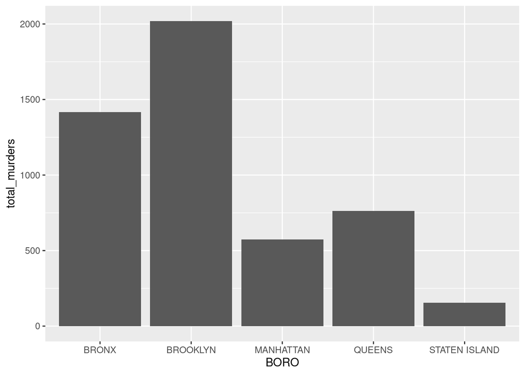

```r
murders_by_region %>%
  ggplot(aes(x = BORO, y = total_murders)) +
  geom_col()
```

The next graph will show the number of murders as a percentage of shootings for each region.

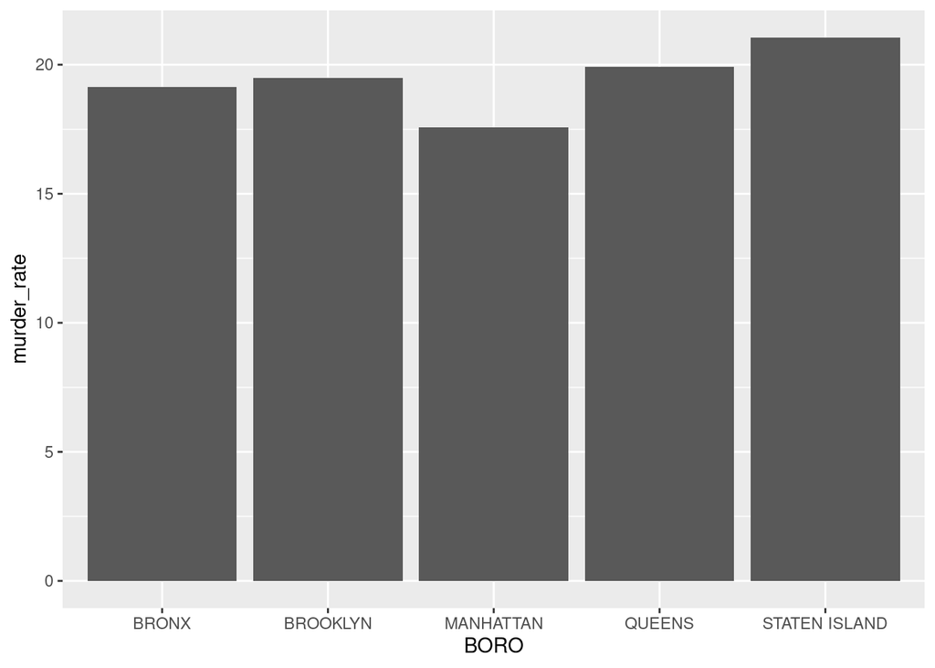

```r
murder_rate_by_region <- nypd_data_cleaned %>%
  group_by(BORO) %>%
  summarize(murder_rate = 100 * sum(STATISTICAL_MURDER_FLAG) / (sum(STATISTICAL_MURDER_FLAG) + sum(!STATISTICAL_MURDER_FLAG))) %>%
  ungroup()

murder_rate_by_region %>%
  ggplot(aes(x = BORO, y = murder_rate)) +
  geom_col()
```

## Analysis

This graph shows that there are more murders in Brooklyn as compared to the other regions in NYC, with Bronx having the second most. Even though there were more murders in those regions though, the rate of murders to crime was about even across all the boro’s. This leads us to believe that there are more crimes in Brooklyn and the Bronx as compared to the other regions. Let’s see if this conclusion holds up consistently over time or if there were simply a few years with high numbers of murders in the area. The following graphs will chart the change in murder rates for each Boro with respect to time.

```r
murder_rate_by_region <- nypd_data_cleaned %>%
  group_by(BORO, DATE) %>%
  summarize(murders = sum(STATISTICAL_MURDER_FLAG),
            crimes = sum(STATISTICAL_MURDER_FLAG) + sum(!STATISTICAL_MURDER_FLAG)) %>%
  mutate(running_murder_rate = 100 * cumsum(murders) / cumsum(crimes)) %>%
  select(BORO, DATE, running_murder_rate) %>%
  ungroup()
```

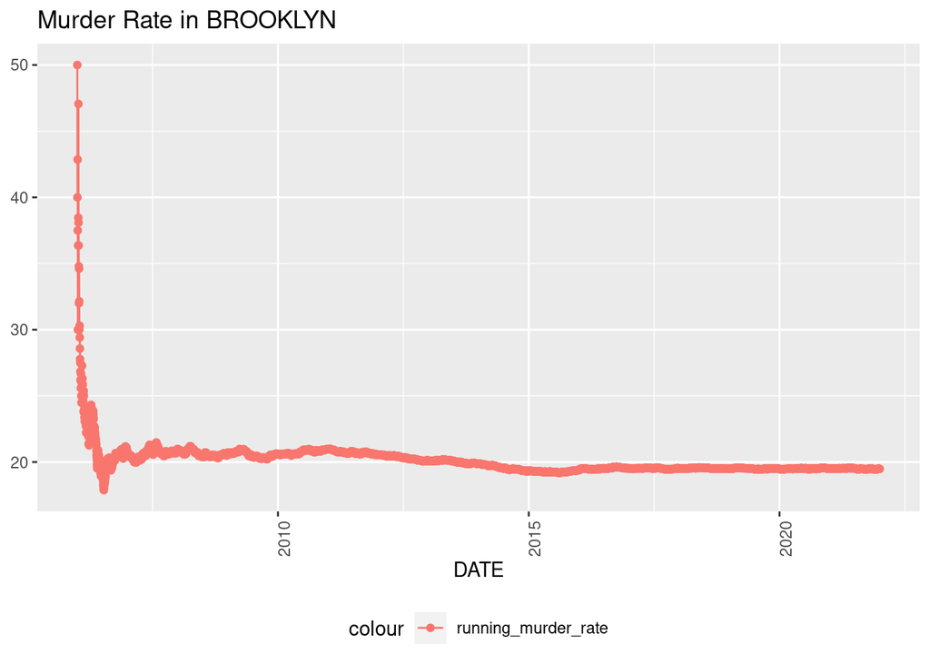

```r
region <- "BROOKLYN"
murder_rate_by_region %>%
  filter(BORO == region) %>%
  ggplot(aes(x = DATE, y = running_murder_rate)) +
  geom_line(aes(color = "running_murder_rate")) +
  geom_point(aes(color = "running_murder_rate")) +
  theme(legend.position = "bottom",
        axis.text.x = element_text(angle = 90)) +
  labs(title = str_c("Murder Rate in ", region), y = NULL)
```

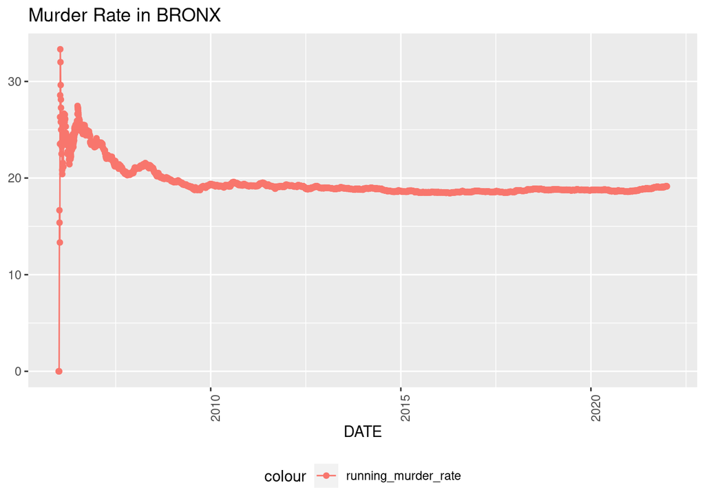

```r
region <- "BRONX"
murder_rate_by_region %>%
  filter(BORO == region) %>%
  ggplot(aes(x = DATE, y = running_murder_rate)) +
  geom_line(aes(color = "running_murder_rate")) +
  geom_point(aes(color = "running_murder_rate")) +
  theme(legend.position = "bottom",
        axis.text.x = element_text(angle = 90)) +
  labs(title = str_c("Murder Rate in ", region), y = NULL)
```

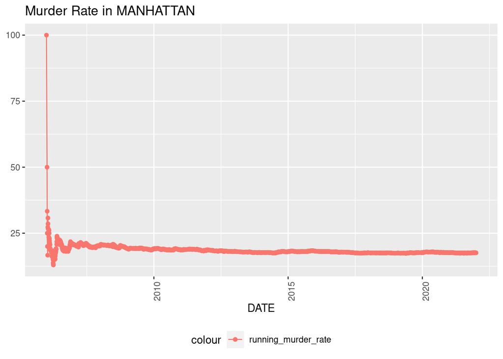

```r
region <- "MANHATTAN"
murder_rate_by_region %>%
  filter(BORO == region) %>%
  ggplot(aes(x = DATE, y = running_murder_rate)) +
  geom_line(aes(color = "running_murder_rate")) +
  geom_point(aes(color = "running_murder_rate")) +
  theme(legend.position = "bottom",
        axis.text.x = element_text(angle = 90)) +
  labs(title = str_c("Murder Rate in ", region), y = NULL)
```

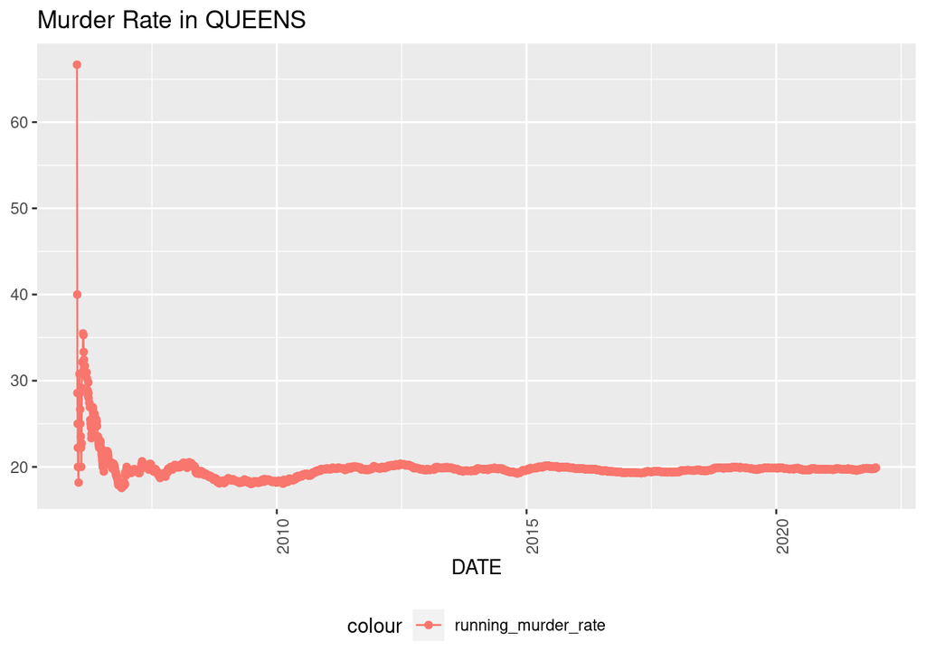

```r
region <- "QUEENS"
murder_rate_by_region %>%
  filter(BORO == region) %>%
  ggplot(aes(x = DATE, y = running_murder_rate)) +
  geom_line(aes(color = "running_murder_rate")) +
  geom_point(aes(color = "running_murder_rate")) +
  theme(legend.position = "bottom",
        axis.text.x = element_text(angle = 90)) +
  labs(title = str_c("Murder Rate in ", region), y = NULL)
```

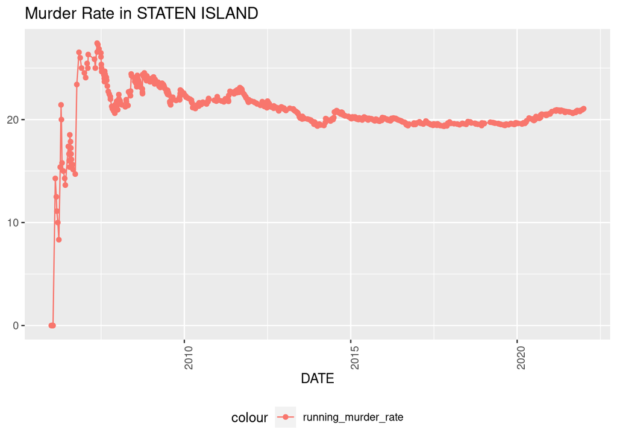

```r
region <- "STATEN ISLAND"
murder_rate_by_region %>%
  filter(BORO == region) %>%
  ggplot(aes(x = DATE, y = running_murder_rate)) +
  geom_line(aes(color = "running_murder_rate")) +
  geom_point(aes(color = "running_murder_rate")) +
  theme(legend.position = "bottom",
        axis.text.x = element_text(angle = 90)) +
  labs(title = str_c("Murder Rate in ", region), y = NULL)
```

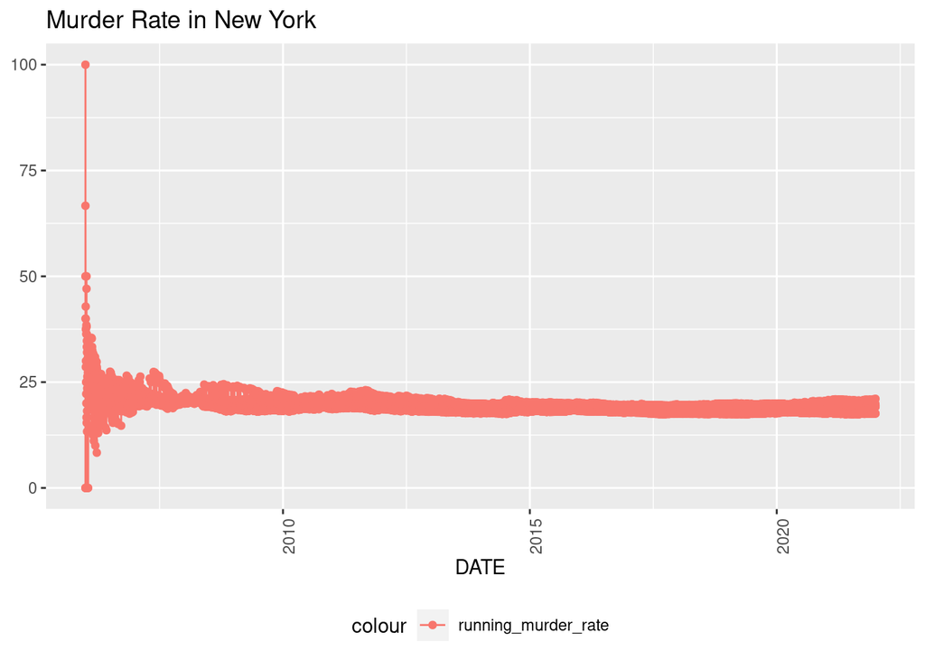

```r
murder_rate_by_region %>%
  ggplot(aes(x = DATE, y = running_murder_rate)) +
  geom_line(aes(color = "running_murder_rate")) +
  geom_point(aes(color = "running_murder_rate")) +
  theme(legend.position = "bottom",
        axis.text.x = element_text(angle = 90)) +
  labs(title = str_c("Murder Rate in New York"), y = NULL)
```